# Fun with R: Ecological data analysis in R

### Type I, II, and III ANOVAs

https://besjournals.onlinelibrary.wiley.com/doi/pdf/10.1111/j.1365-2656.2009.01634.x

It turns out that there is not just one way to calculate ANOVAs. In fact, there are three different types - called, Type 1, 2, and 3 (or Type I, II and III). These types differ in how they calculate variability (specifically the **sums of of squares**). If your data is relatively **BALANCED**, meaning that there are relatively equal numbers of observations in each group, then all three types will give you the same answer. However, if your data are **UNBALANCED**, meaning that some groups of data have many more observations than others, then you need to use Type II or Type III. The **ANCOVA** model is an expection wher this issue must be considered.

The standard `aov` function in `base` package uses **Type I** sums of squares. Therefore, it is appropriate when your data are **BALANCED**. If your data are **UNBALANCED**, you should consider an ANOVA with Type II or Type III sums of squares. To do this, you can use the `Anova` function in the `car` package. The `Anova` function has an argument called type that allows you to specify the type of ANOVA you want to calculate.

First, create a regression object with `lm`. As you’ll see, the `Anova` function requires you to enter a regression object as the main argument, and not a formula and dataset. That is, you need to first create a regression object from the data with `lm` (or `glm`), and then enter that object into the `Anova` function.

```r
# Step 1: Calculate regression object with lm()
time.lm <- lm(formula = time ~ type + cleaner, data = poopdeck)
```

Now that I’ve created the regression object `time.lm`, I can calculate the three different types of ANOVAs by entering the object as the main argument to either `aov` for a Type I ANOVA, or `Anova` in the `car` package for a Type I II or III ANOVA:

```r
# Type I ANOVA - aov()
time.I.aov <- aov(time.lm)
# or anova(time.lm)

# Type II ANOVA - Anova(type = 2)
time.II.aov <- car::Anova(time.lm, type = 2)

# Type III ANOVA - Anova(type = 3)
time.III.aov <- car::Anova(time.lm, type = 3)
```

As it happens, the data in the `poopdeck` dataframe are perfectly balanced (so we’ll get exactly the same result for each ANOVA type. However, if they were not balanced, then we should not use the Type I ANOVA calculated with the `aov` function.

To see if your data are balanced, you can use the function:

```r
# Are observations in the poopdeck data balanced?
with(poopdeck, table(cleaner, type))
```

```
##        type
## cleaner parrot shark
##       a    100   100
##       b    100   100
##       c    100   100
```

As you can see, in the `poopdeck` data set, the observations are perfectly balanced (see previously the justifcation for **full-factorial, between-subjects ANOVAs**) , so it doesn’t matter which type of ANOVA we use to analyze the data.

For more detail on the different types, check out [here](https://mcfromnz.wordpress.com/2011/03/02/anova-type-iiiiii-ss-explained/) for a techincal discussion. Also check [Hector et al. (2010)](https://besjournals.onlinelibrary.wiley.com/doi/pdf/10.1111/j.1365-2656.2009.01634.x) for a discussion on the topic in the field of ecology and evolution.

**A quick summary**

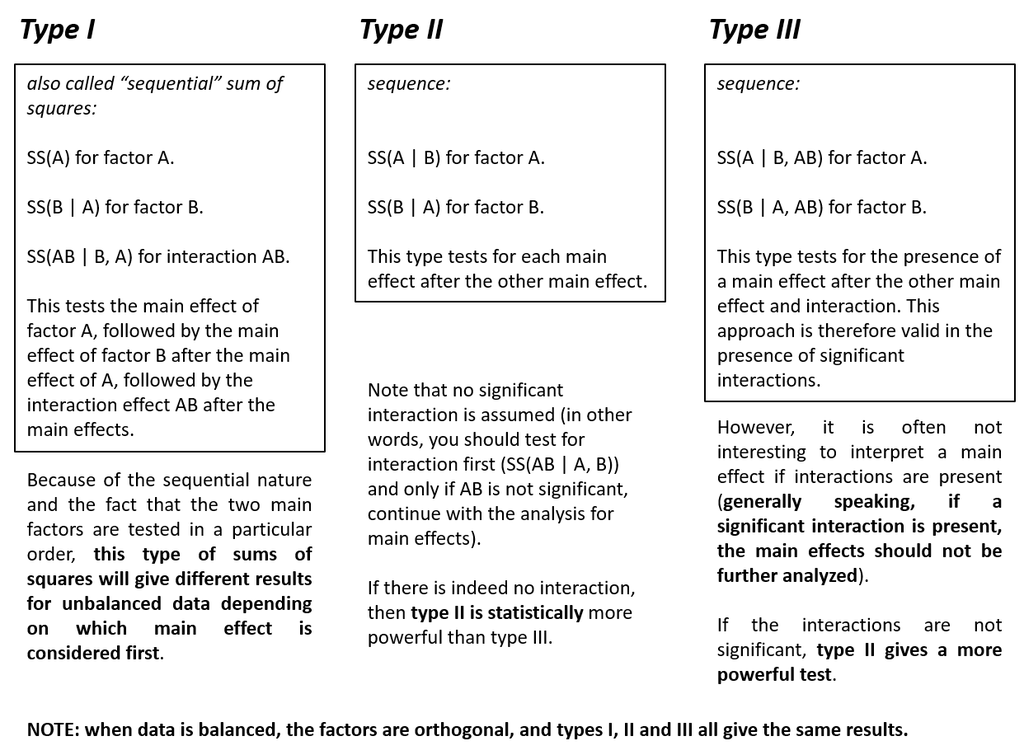

### Additional information and assumption

You can get a lot of interesting information from ANOVA objects. To see everything that’s stored in one ANOVA, run `names` on an ANOVA object. For example, here’s what’s in our last ANOVA object (note the `contrasts` that may be important to know when applying Type II, or III ANOVA):

```r
names(cleaner.type.int.aov)
```

```
##  [1] "coefficients"  "residuals"     "effects"       "rank"
##  [5] "fitted.values" "assign"        "qr"            "df.residual"
##  [9] "contrasts"     "xlevels"       "call"          "terms"
## [13] "model"
```

```r
poopdeck$int.fit <- cleaner.type.int.aov$fitted.values
poopdeck$me.fit <- cleaner.type.aov$fitted.values
```

Now, we can calculate how far each model’s fits were from the true data as follows:

```r
mean(abs(poopdeck$int.fit - poopdeck$time))
```

```
## [1] 15.35173
```

```r
mean(abs(poopdeck$me.fit - poopdeck$time))
```

```
## [1] 16.5351
```

As you can see, the **interaction model** was off from the data by `15.35` minutes on average, while the **main effects model** was off from the data by `16.54` on average. This is not surprising as the interaction model is more complex than the main effects only model. However, b careful, just because the interaction model is better at fitting the data doesn’t necessarily mean that the interaction is either meaningful or reliable.

#### Model assumptions

The `residuals` are available in your anova object. We previously saw how to examine graphically those residuals for **normality** and **homoscedasticity**. Let’s test them here from our anova object:

```r
shapiro.test(cleaner.type.int.aov$residuals) # test our residuals vs a normal distribution
```

```
##
##  Shapiro-Wilk normality test
##
## data:  cleaner.type.int.aov$residuals
## W = 0.99641, p-value = 0.1962
```

```r
bartlett.test(cleaner.type.int.aov$residuals ~ interaction(cleaner, type), data = poopdeck) # test variance of our residuals in the different groups.
```

```
##
##  Bartlett test of homogeneity of variances
##
## data:  cleaner.type.int.aov$residuals by interaction(cleaner, type)
## Bartlett's K-squared = 7.3232, df = 5, p-value = 0.1977
```

The null hypothesis of **normal distribution** and **homoscedasticity** are accepted: there is no significant difference (p > 0.05) from a normal distribution and no significant heterogeneity

#### Transformations

Checking the assumptions of regression models is critical to look at possible issues in our models. The response variable can be transformed in order to:

- **stabilize** the variance (e.g. log transformation such as `log(Petal.Width)` in our `lm`) - data not normally distributed around their average
- **accomodate** strictly positive variable using Box-Cox Transformations

In addition to transformation of the response variable, we can also consider transformations of predictor variables. Sometimes these transformations can help with violation of model assumptions, and other times they can be used to simply fit a more flexible model (e.g. log, polynomials).

Below is a linear model equation where the original dependent variable $y$, has been natural log transformed. That is, the natural log has been taken of each individual value of $y$ and that is being used as the dependent variable.

$$ln(y_i) = \beta_0 + \beta_1x_1 + \beta_1x_1 + \beta_2x_2 + ... + \epsilon_i$$
The linear model with the log transformation is providing an equation for an individual value of ln(y). We could also write it as follows, where we are modeling the mean of $ln(y)$ (note the error term is no longer present):

$$\mu_{ln(y)} = \beta_0 + \beta_1x_1 + \beta_1x_1 + \beta_2x_2 + ...$$
This makes the difference a bit clearer. When we transform the data in a linear model, we are no longer claiming that $y$ is normally distributed around a mean, given the $x$ values — we are claiming that our new outcome variable, $ln(y_i)$, is normally distributed.

This topic is extensively cover in online documentation in order for your model to meet the assumptions of normality and homoscedasticity. In addition, a violation of thes assumption may originate because your data simpy does not belong to a Gaussian family

## Data distribution and link function

Here is a brief summary of the data distributions you might encounter most often (especially in ecology):

Choosing the right **family** for your analysis is important and should you should think carefully about it before building your model. It could be frustrating to spend tons of time running models, plotting their results and writing them up only to realise that all along you should have used *e.g.* a Poisson distribution instead of a Gaussian one.

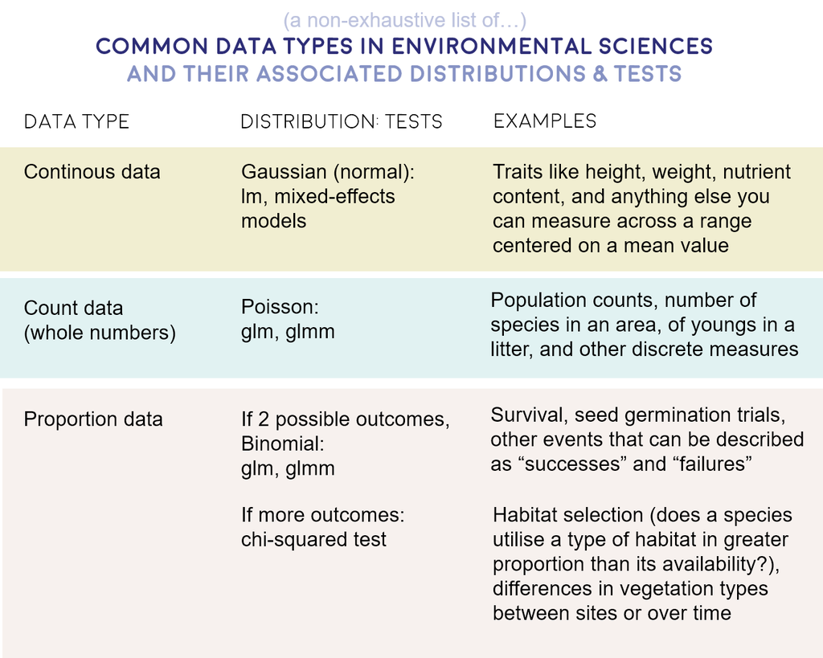

**Generalized linear models (GLM)** — and generalized linear mixed models —are called generalized linear because they connect a model’s outcome to its predictors in a linear way. The function used to make this connection is called a link function. Link functions sounds like an exotic term, but they’re actually much simpler than they sound.

For example, **Poisson regression** (commonly used for outcomes that are counts) makes use of a natural log link function as follows:

$$ln(\mu_y) = \beta_0 + \beta_1x_1 + \beta_1x_1 + \beta_2x_2 + ...$$

Clearly, there is not a direct linear relationship of the $x$ variables to the average count, but there is a “sort of linear” relationship happening: a function of the mean of $y$ is related to a linear combination of $x$ variables. In other words, the linear model has now been generalized to a bigger type of situation.

This can lead to confusion, though, because on the surface it looks very similar to what happens when we transform the dependent variable in a linear model, like a linear regression as previously mentioned

The key thing to understand is that the **natural log link function** is a function of the **mean of $y$**, not the **$y$ values** themselves as previously mentioned

**General linear model** met all the assumptions: normal distribution, homoscedasticity, etc. However, quite often in ecology and environmental science that is not the case and then we use different data distributions. Here we will talk about **Poisson** and **binomial** distribution. To use them, we need to run **generalised linear models** using the function `glm`.

### A model with a Poisson distribution

Import the `shagLPI` dataset and check it’s summary using `summary(shagLPI)`. The data represent population trends for European Shags on the Isle of May and are available from the [Living Planet Index](https://livingplanetindex.org/home/index).

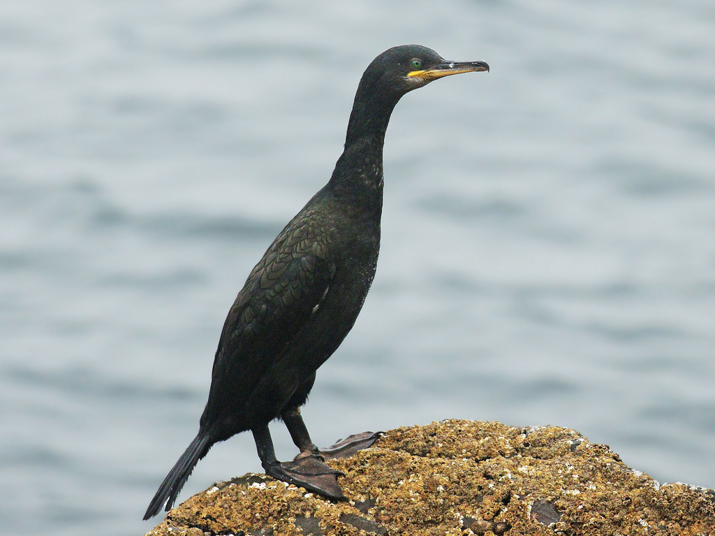

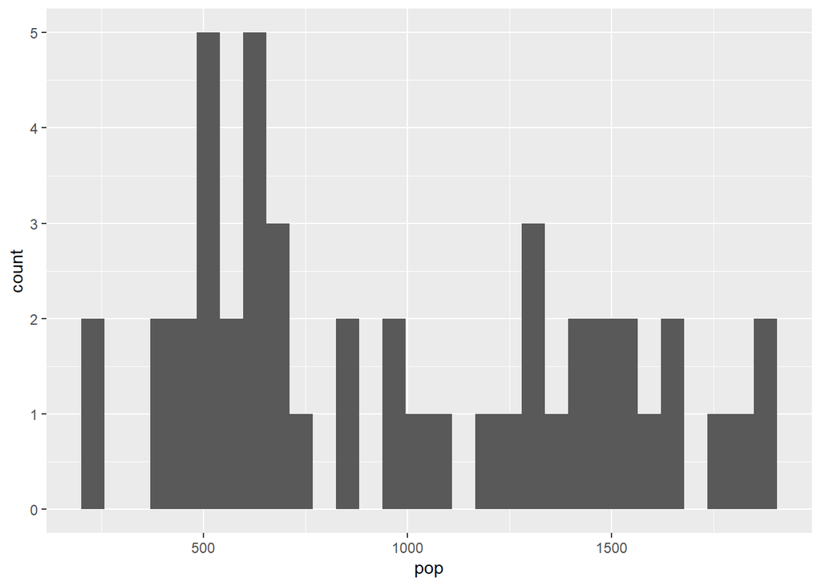

```r
shag <- read.csv("Data/shagLPI.csv", header = TRUE)
shag$year <- as.numeric(shag$year)  #  year should be a numeric variable
shag.hist <- ggplot(shag, aes(pop)) + geom_histogram()
shag.hist
```

Our pop variable represents count abundance data, *i.e.* integer values (whole European Shags) so a Poisson distribution is appropriate here. Often count abundance data are zero-inflated and skewed towards the right. Here our data are not like that, but if they were, a Poisson distribution would still have been appropriate.

```r
shag.m <- glm(pop ~ year, family = poisson, data = shag)
summary(shag.m)
```

```
##
## Call:
## glm(formula = pop ~ year, family = poisson, data = shag)
##
## Deviance Residuals:
##     Min       1Q   Median       3Q      Max
## -26.013  -13.223   -4.839   10.585   23.806
##
## Coefficients:
##               Estimate Std. Error z value Pr(>|z|)
## (Intercept) 50.4891423  1.0556692   47.83   <2e-16 ***
## year        -0.0219126  0.0005309  -41.28   <2e-16 ***
## ---
## Signif. codes:  0 '***' 0.001 '**' 0.01 '*' 0.05 '.' 0.1 ' ' 1
##
## (Dispersion parameter for poisson family taken to be 1)
##
##     Null deviance: 11407.3  on 46  degrees of freedom
## Residual deviance:  9710.8  on 45  degrees of freedom
## AIC: 10119
##
## Number of Fisher Scoring iterations: 4
```

From the summary of our model we can see that European Shag abundance varies significantly based on the predictor year. Let’s visualise how European Shag abundance has changed through the years:

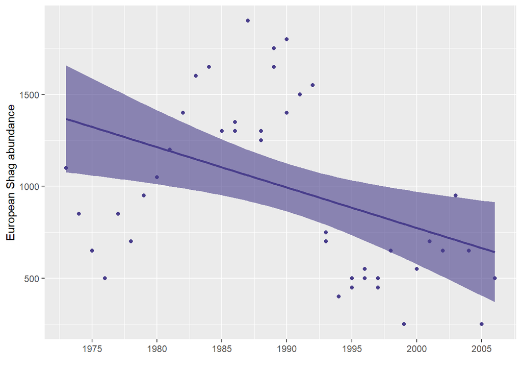

```r
shag.p <- ggplot(shag, aes(x = year, y = pop)) +
    geom_point(colour = "#483D8B") +
    geom_smooth(method = glm, colour = "#483D8B", fill = "#483D8B", alpha = 0.6) +
    scale_x_continuous(breaks = c(1975, 1980, 1985, 1990, 1995, 2000, 2005)) +
    labs(x = " ", y = "European Shag abundance")
shag.p
```

### A model with a binomial distribution

We will now work this the `Weevil_damage`. We can examine if damage to Scot’s pine by weevils (a binary, `TRUE`/`FALSE` variable) varies based on the block in which the trees are located. You can imagine that different blocks represent different Scot’s pine populations, and perhaps some of them will be particularly vulnerable to weevils? Because of the binary nature of the response variable (true or false), a binomial model is appropriate here.

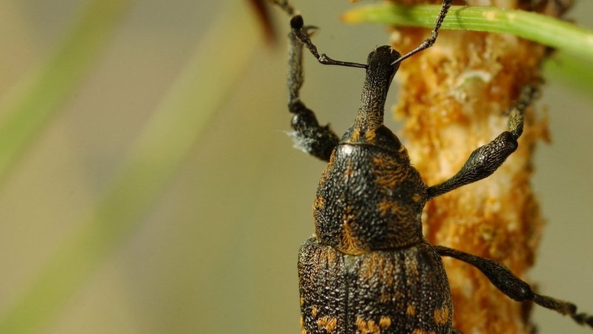

```r
Weevil_damage <- read.csv("Data/Weevil_damage.csv")
Weevil_damage$block <- as.factor(Weevil_damage$block) # Making block a factor
weevil.m <- glm(damage_T_F ~ block, family = binomial, data = Weevil_damage)
summary(weevil.m)
```

```
##
## Call:
## glm(formula = damage_T_F ~ block, family = binomial, data = Weevil_damage)
##
## Deviance Residuals:
##     Min       1Q   Median       3Q      Max
## -2.1686   0.4474   0.6156   0.8906   0.9005
##
## Coefficients:
##             Estimate Std. Error z value Pr(>|z|)
## (Intercept)   1.5672     0.2041   7.677 1.63e-14 ***
## block2       -0.8471     0.2621  -3.232 0.001230 **
## block3        0.6841     0.3328   2.056 0.039802 *
## block4       -0.8740     0.2617  -3.340 0.000837 ***
## ---
## Signif. codes:  0 '***' 0.001 '**' 0.01 '*' 0.05 '.' 0.1 ' ' 1
##
## (Dispersion parameter for binomial family taken to be 1)
##
##     Null deviance: 728.25  on 671  degrees of freedom
## Residual deviance: 686.56  on 668  degrees of freedom
## AIC: 694.56
##
## Number of Fisher Scoring iterations: 4
```

The probability of a pine tree enduring damage from weevils does vary significantly based on the block in which the tree was located.

You won’t get a R squared value to assess the goodness of fit of your model, but you can get at that by looking at the difference between the Null deviance (variability explained by a null model, *e.g.* `glm(damage_T_F ~ 1, family = binomial, data = Weevil_damage)` and the Residual deviance, *e.g.* the amount of variability that remains after you’ve explained some away by your explanatory variable. In short, the bigger the reduction in deviance, the better a job your model is doing at explaining a relationship.

## Taking Account of the Random Effects

A **random effect** can be used in the case of **paired data** or **repeated measures**. As an example, if we are measuring the **length** of several **individual** plants, the measurements are paired within each individual. That is, we want to statistically match the length at different days of one individual, since we supposed we may have difference in the initial length and therefore different growth. Therefore, in this case, the variable ‘individual’ must be include in the model as a random variable. Often, we want to disregard the effect of this random factor (e.g. individual difference) to focus on another one (e.g. growth itself). Each Individual could be thought of has a block including a measurement for the length.

The concept of random variables is not easy to get, so it is okay to not completely understand the full concept at this point. Whether a variable should be considered a **fixed** or **random** variable will also depend on the interpretation of the person doing the analysis, adding sometime one layer of subjectivity.

**Mixed effects models**

When a model includes both fixed effects and random effects, it is called a *mixed effects model*.

For more complex models, specifying random effects can become difficult. Random effects can be **crossed** with one another or can be **nested** within one another. Also, **correlation structures** for the random effects can be specified. However, here, we will just keep it simple using an example with our `rairuoho` data set.

```r
rairuoho<-read.table('Data/rairuoho.txt',header=T, sep="\t", dec=".")
rairuoho$ID<-rownames(rairuoho)
rai<-rairuoho %>% pivot_longer(day3:day8, names_to = "day", values_to = "length")
rai$day<-parse_number(rai$day)
rai
```

```
## # A tibble: 288 x 10
##    germinate bed    treatment spatial1 spatial2   row column ID      day length
##        <int> <chr>  <chr>     <chr>    <chr>    <int>  <int> <chr> <dbl>  <int>
##  1        18 paper4 nutrient  upper    left         1      1 1         3      2
##  2        18 paper4 nutrient  upper    left         1      1 1         4     13
##  3        18 paper4 nutrient  upper    left         1      1 1         5     34
##  4        18 paper4 nutrient  upper    left         1      1 1         6     85
##  5        18 paper4 nutrient  upper    left         1      1 1         7    112
##  6        18 paper4 nutrient  upper    left         1      1 1         8    121
##  7        19 mould1 nutrient  upper    left         2      1 2         3      5
##  8        19 mould1 nutrient  upper    left         2      1 2         4     22
##  9        19 mould1 nutrient  upper    left         2      1 2         5     60
## 10        19 mould1 nutrient  upper    left         2      1 2         6     95
## # ... with 278 more rows
```

We want to examine the length of the plant ($y$) as a function of the day ($x$). In this case, the initial size of the plant varies. It become obvious that the growth of each pant should be examined individually.

#### Mixed model with `lmer`

One way to construct a mixed effects model for interval/ratio data is with the function `lmer` from the package `lme4` package. However you will not get the **p-value** of the overall model, because you need to carefully think on how to extract this information because of the complexity of the input you can have.

As a technical note, the 1 indicates that an intercept is to be fitted for each level of the random variable. As another technical note, `REML` stands for restricted maximum likelihood. It is a method of fitting the model, and is often considered better than fitting with a conventional ML (maximum likelihood) method.

```r
lmer.rai<-lmer(length ~ day + (1|ID), data=rai, REML=TRUE) # REML default
summary(lmer.rai)
```

```
## Linear mixed model fit by REML. t-tests use Satterthwaite's method [
## lmerModLmerTest]
## Formula: length ~ day + (1 | ID)
##    Data: rai
##
## REML criterion at convergence: 2219.4
##
## Scaled residuals:
##      Min       1Q   Median       3Q      Max
## -2.45069 -0.66336 -0.00108  0.68279  2.41821
##
## Random effects:
##  Groups   Name        Variance Std.Dev.
##  ID       (Intercept) 77.23    8.788
##  Residual             98.81    9.940
## Number of obs: 288, groups:  ID, 48
##
## Fixed effects:
##             Estimate Std. Error      df t value Pr(>|t|)
## (Intercept)  -62.578      2.347 226.509  -26.66   <2e-16 ***
## day           21.994      0.343 239.000   64.13   <2e-16 ***
## ---
## Signif. codes:  0 '***' 0.001 '**' 0.01 '*' 0.05 '.' 0.1 ' ' 1
##
## Correlation of Fixed Effects:
##     (Intr)
## day -0.804
```

One way to extract the p-value is by using the `lmerTest` package to produce an analysis of variance with *p*-values for model effects.

```r
anova(lmer.rai)
```

```
## Type III Analysis of Variance Table with Satterthwaite's method
##     Sum Sq Mean Sq NumDF DenDF F value    Pr(>F)
## day 406340  406340     1   239  4112.4 < 2.2e-16 ***
## ---
## Signif. codes:  0 '***' 0.001 '**' 0.01 '*' 0.05 '.' 0.1 ' ' 1
```

The `rand` function from the `lmerTest` package will test the random effects in the model

```r
rand(lmer.rai)
```

```
## ANOVA-like table for random-effects: Single term deletions
##
## Model:
## length ~ day + (1 | ID)
##          npar  logLik    AIC    LRT Df Pr(>Chisq)
## <none>      4 -1109.7 2227.4
## (1 | ID)    3 -1150.5 2307.1 81.694  1  < 2.2e-16 ***
## ---
## Signif. codes:  0 '***' 0.001 '**' 0.01 '*' 0.05 '.' 0.1 ' ' 1
```

In addition, The `lmerTest` package is used to produce an analysis of variance with p-values for model effects. However, in our case, a simple linear regression with a random factor, we will use another function to extract the p-value from our model.

#### Mixed model with `nlme`

We will use the function `lme` form the package `nlme`

Notice the grammar in the `lme` function that defines the model is slightly different form the previous example: the option `random = ~1|ID` is added to the model to indicate that `ID` is the random term.

```r
lme.rai = lme(length ~ day, random=~1|ID, data=rai)
summary(lme.rai)
```

```
## Linear mixed-effects model fit by REML
##  Data: rai
##        AIC      BIC    logLik
##   2227.398 2242.022 -1109.699
##
## Random effects:
##  Formula: ~1 | ID
##         (Intercept) Residual
## StdDev:    8.788108 9.940262
##
## Fixed effects: length ~ day
##                 Value Std.Error  DF   t-value p-value
## (Intercept) -62.57837 2.3474146 239 -26.65842       0
## day          21.99405 0.3429716 239  64.12790       0
##  Correlation:
##     (Intr)
## day -0.804
##
## Standardized Within-Group Residuals:
##          Min           Q1          Med           Q3          Max
## -2.450692248 -0.663363308 -0.001084166  0.682786502  2.418207934
##
## Number of Observations: 288
## Number of Groups: 48
```

The random effects in the model can be tested by comparing the model to a model fitted with just the fixed effects and excluding the random effects.

```r
lm.rai<-lm(length ~ day, data= rai)
anova (lme.rai, lm.rai)
```

```
##         Model df      AIC      BIC    logLik   Test  L.Ratio p-value
## lme.rai     1  4 2227.398 2242.022 -1109.699
## lm.rai      2  3 2307.092 2318.060 -1150.546 1 vs 2 81.69417  <.0001
```

**Random Intercept and slope model**

the “~1” specifies the random intercept and “Day|ID” would allow the slope to vary among individuals. However,it starts to be much more advanced. You may find entire book on mixed effect model in R.